# Промышленность: обработка стали

### Анализ `data_bulk_new.csv` и `data_bulk_time_new.csv`

#### Знакомство с данными

```python
bulk.head()
```

|  | key | bulk_1 | bulk_2 | bulk_3 | bulk_4 | bulk_5 | bulk_6 | bulk_7 | bulk_8 | bulk_9 | bulk_10 | bulk_11 | bulk_12 | bulk_13 | bulk_14 | bulk_15 |
| --- | --- | --- | --- | --- | --- | --- | --- | --- | --- | --- | --- | --- | --- | --- | --- | --- |
| 0 | 1 | NaN | NaN | NaN | 43.0 | NaN | NaN | NaN | NaN | NaN | NaN | NaN | 206.0 | NaN | 150.0 | 154.0 |
| 1 | 2 | NaN | NaN | NaN | 73.0 | NaN | NaN | NaN | NaN | NaN | NaN | NaN | 206.0 | NaN | 149.0 | 154.0 |
| 2 | 3 | NaN | NaN | NaN | 34.0 | NaN | NaN | NaN | NaN | NaN | NaN | NaN | 205.0 | NaN | 152.0 | 153.0 |
| 3 | 4 | NaN | NaN | NaN | 81.0 | NaN | NaN | NaN | NaN | NaN | NaN | NaN | 207.0 | NaN | 153.0 | 154.0 |
| 4 | 5 | NaN | NaN | NaN | 78.0 | NaN | NaN | NaN | NaN | NaN | NaN | NaN | 203.0 | NaN | 151.0 | 152.0 |

```python
bulk_time.head()
```

|  | key | bulk_1 | bulk_2 | bulk_3 | bulk_4 | bulk_5 | bulk_6 | bulk_7 | bulk_8 | bulk_9 | bulk_10 | bulk_11 | bulk_12 | bulk_13 | bulk_14 | bulk_15 |
| --- | --- | --- | --- | --- | --- | --- | --- | --- | --- | --- | --- | --- | --- | --- | --- | --- |
| 0 | 1 | NaN | NaN | NaN | 2019-05-03 11:28:48 | NaN | NaN | NaN | NaN | NaN | NaN | NaN | 2019-05-03 11:24:31 | NaN | 2019-05-03 11:14:50 | 2019-05-03 11:10:43 |
| 1 | 2 | NaN | NaN | NaN | 2019-05-03 11:36:50 | NaN | NaN | NaN | NaN | NaN | NaN | NaN | 2019-05-03 11:53:30 | NaN | 2019-05-03 11:48:37 | 2019-05-03 11:44:39 |
| 2 | 3 | NaN | NaN | NaN | 2019-05-03 12:32:39 | NaN | NaN | NaN | NaN | NaN | NaN | NaN | 2019-05-03 12:27:13 | NaN | 2019-05-03 12:21:01 | 2019-05-03 12:16:16 |
| 3 | 4 | NaN | NaN | NaN | 2019-05-03 12:43:22 | NaN | NaN | NaN | NaN | NaN | NaN | NaN | 2019-05-03 12:58:00 | NaN | 2019-05-03 12:51:11 | 2019-05-03 12:46:36 |
| 4 | 5 | NaN | NaN | NaN | 2019-05-03 13:30:47 | NaN | NaN | NaN | NaN | NaN | NaN | NaN | 2019-05-03 13:30:47 | NaN | 2019-05-03 13:34:12 | 2019-05-03 13:30:47 |

```python
bulk.info()
```

```
<class 'pandas.core.frame.DataFrame'>
RangeIndex: 3129 entries, 0 to 3128
Data columns (total 16 columns):
 #   Column   Non-Null Count  Dtype
---  ------   --------------  -----
 0   key      3129 non-null   int64
 1   bulk_1   252 non-null    float64
 2   bulk_2   22 non-null     float64
 3   bulk_3   1298 non-null   float64
 4   bulk_4   1014 non-null   float64
 5   bulk_5   77 non-null     float64
 6   bulk_6   576 non-null    float64
 7   bulk_7   25 non-null     float64
 8   bulk_8   1 non-null      float64
 9   bulk_9   19 non-null     float64
 10  bulk_10  176 non-null    float64
 11  bulk_11  177 non-null    float64
 12  bulk_12  2450 non-null   float64
 13  bulk_13  18 non-null     float64
 14  bulk_14  2806 non-null   float64
 15  bulk_15  2248 non-null   float64
dtypes: float64(15), int64(1)
memory usage: 391.3 KB
```

```python
bulk_time.info()
```

```
<class 'pandas.core.frame.DataFrame'>
RangeIndex: 3129 entries, 0 to 3128
Data columns (total 16 columns):
 #   Column   Non-Null Count  Dtype
---  ------   --------------  -----
 0   key      3129 non-null   int64
 1   bulk_1   252 non-null    object
 2   bulk_2   22 non-null     object
 3   bulk_3   1298 non-null   object
 4   bulk_4   1014 non-null   object
 5   bulk_5   77 non-null     object
 6   bulk_6   576 non-null    object
 7   bulk_7   25 non-null     object
 8   bulk_8   1 non-null      object
 9   bulk_9   19 non-null     object
 10  bulk_10  176 non-null    object
 11  bulk_11  177 non-null    object
 12  bulk_12  2450 non-null   object
 13  bulk_13  18 non-null     object
 14  bulk_14  2806 non-null   object
 15  bulk_15  2248 non-null   object
dtypes: int64(1), object(15)
memory usage: 391.3+ KB
```

Пропуски в датафрейме `bulk` означают отсутствие данных о внесении материала. По количеству пропусков и датафрейму `bulk_time` можно сделать вывод, что эти материалы не вноисились, заменив проуски `bulk` нулями во время предобработки.

Неверный тип данных в датафрейме `bulk_time`, исправляю:

```python
bulk_time[bulk_time.columns[1:]] = pd.to_datetime(bulk_time[bulk_time.columns[1:]].stack()).unstack()
```

```python
bulk[bulk.columns[1:]].describe().T
```

|  | count | mean | std | min | 25% | 50% | 75% | max |
| --- | --- | --- | --- | --- | --- | --- | --- | --- |
| bulk_1 | 252.0 | 39.242063 | 18.277654 | 10.0 | 27.00 | 31.0 | 46.00 | 185.0 |
| bulk_2 | 22.0 | 253.045455 | 21.180578 | 228.0 | 242.00 | 251.5 | 257.75 | 325.0 |
| bulk_3 | 1298.0 | 113.879045 | 75.483494 | 6.0 | 58.00 | 97.5 | 152.00 | 454.0 |
| bulk_4 | 1014.0 | 104.394477 | 48.184126 | 12.0 | 72.00 | 102.0 | 133.00 | 281.0 |
| bulk_5 | 77.0 | 107.025974 | 81.790646 | 11.0 | 70.00 | 86.0 | 132.00 | 603.0 |
| bulk_6 | 576.0 | 118.925347 | 72.057776 | 17.0 | 69.75 | 100.0 | 157.00 | 503.0 |
| bulk_7 | 25.0 | 305.600000 | 191.022904 | 47.0 | 155.00 | 298.0 | 406.00 | 772.0 |
| bulk_8 | 1.0 | 49.000000 | NaN | 49.0 | 49.00 | 49.0 | 49.00 | 49.0 |
| bulk_9 | 19.0 | 76.315789 | 21.720581 | 63.0 | 66.00 | 68.0 | 70.50 | 147.0 |
| bulk_10 | 176.0 | 83.284091 | 26.060347 | 24.0 | 64.00 | 86.5 | 102.00 | 159.0 |
| bulk_11 | 177.0 | 76.819209 | 59.655365 | 8.0 | 25.00 | 64.0 | 106.00 | 313.0 |
| bulk_12 | 2450.0 | 260.471020 | 120.649269 | 53.0 | 204.00 | 208.0 | 316.00 | 1849.0 |
| bulk_13 | 18.0 | 181.111111 | 46.088009 | 151.0 | 153.25 | 155.5 | 203.50 | 305.0 |
| bulk_14 | 2806.0 | 170.284747 | 65.868652 | 16.0 | 119.00 | 151.0 | 205.75 | 636.0 |
| bulk_15 | 2248.0 | 160.513345 | 51.765319 | 1.0 | 105.00 | 160.0 | 205.00 | 405.0 |

Для `bulk_8` всего одно наблюдение. В этом признаке нет смысла, его придется удалить.

#### Распределение объема сыпучих материалов

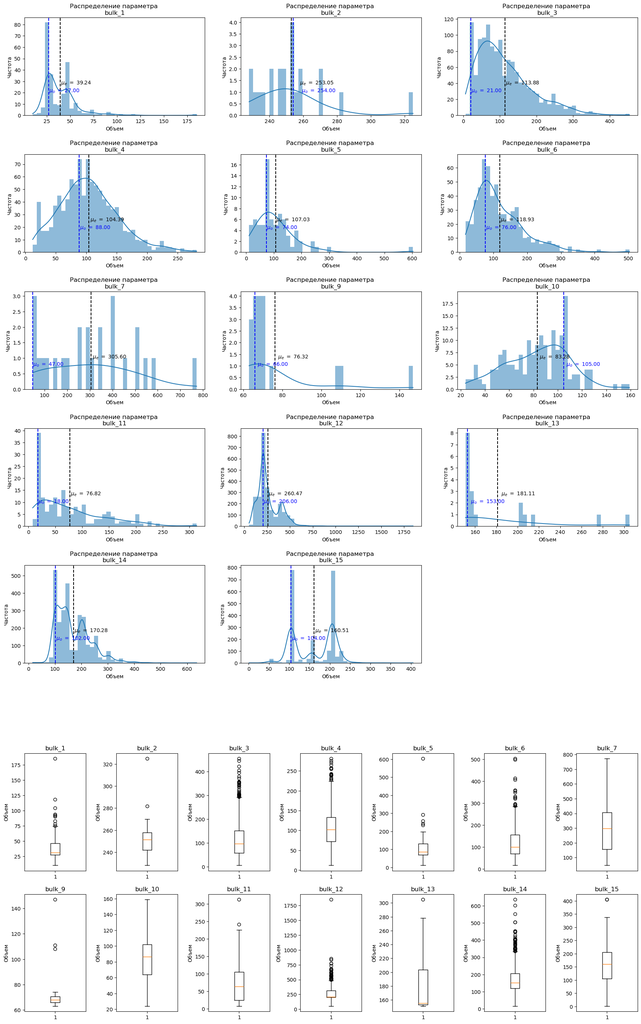

```python
plot_hists_and_boxes(bulk.drop(['key', 'bulk_8'], axis=1),
                       hist_grid_shape=(5, 3), box_grid_shape=(2, 7), bins=40)
```

Многомодальные распределения с правой асимметрией. По графику видны длинные хвосты в объемах некоторых сыпучих материалов, особенно Bulk 12. Выбросы для Bulk 12 и Bulk 5 будут скорректированы наэтапе предобработки.

### Анализ `data_gas_new.csv`

#### Знакомство с данными

```python
gas.head()
```

|  | key | gas_vol |
| --- | --- | --- |
| 0 | 1 | 29.749986 |
| 1 | 2 | 12.555561 |
| 2 | 3 | 28.554793 |
| 3 | 4 | 18.841219 |
| 4 | 5 | 5.413692 |

Расход объема газа на партию, без привязки ко времени.

```python
gas.info()
```

```
<class 'pandas.core.frame.DataFrame'>
RangeIndex: 3239 entries, 0 to 3238
Data columns (total 2 columns):
 #   Column   Non-Null Count  Dtype
---  ------   --------------  -----
 0   key      3239 non-null   int64
 1   gas_vol  3239 non-null   float64
dtypes: float64(1), int64(1)
memory usage: 50.7 KB
```

```python
gas.describe()
```

|  | key | gas_vol |
| --- | --- | --- |
| count | 3239.000000 | 3239.000000 |
| mean | 1621.861377 | 11.002062 |
| std | 935.386334 | 6.220327 |
| min | 1.000000 | 0.008399 |
| 25% | 812.500000 | 7.043089 |
| 50% | 1622.000000 | 9.836267 |
| 75% | 2431.500000 | 13.769915 |
| max | 3241.000000 | 77.995040 |

#### Распределение объема газа

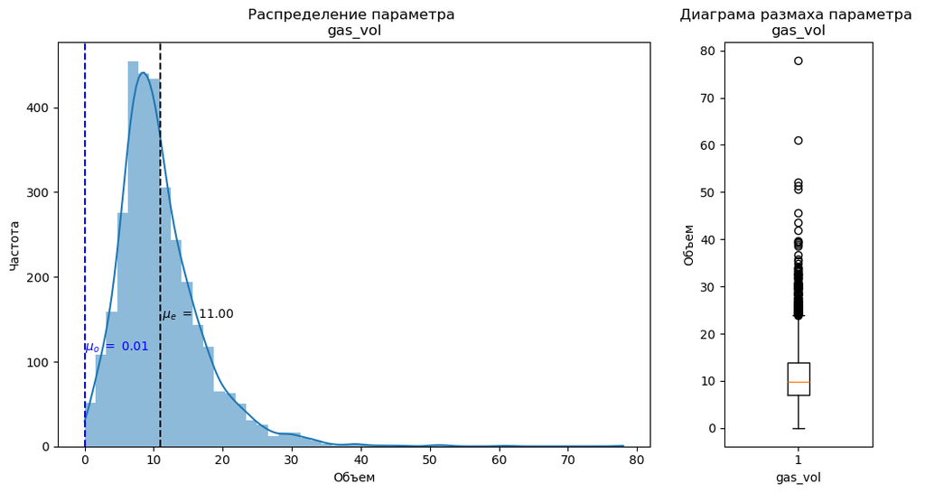

```python
plot_hist_and_box(gas['gas_vol'])
```

Правоасимметричное распределение, среднее значение объема газа - 11, максимальное - 78. Аномалий не найдено, зафиксированные на диаграмме размаха выбросы после значений объема выше 45 выглядят ошибками, их имеет смысл удалить:

```python
gas
```

|  | key | gas_vol |
| --- | --- | --- |
| 0 | 1 | 29.749986 |
| 1 | 2 | 12.555561 |
| 2 | 3 | 28.554793 |
| 3 | 4 | 18.841219 |
| 4 | 5 | 5.413692 |
| ... | ... | ... |
| 3234 | 3237 | 5.543905 |
| 3235 | 3238 | 6.745669 |
| 3236 | 3239 | 16.023518 |
| 3237 | 3240 | 11.863103 |
| 3238 | 3241 | 12.680959 |

3239 rows × 2 columns

```python
gas_keys_to_del = gas[gas['gas_vol'] > 45]['key'].values
gas_keys_to_del
```

```
array([ 117,  280,  322, 2108, 2110, 2570])
```

### Анализ `data_temp_new.csv`

#### Знакомство с данными

```python
temp.head(10)
```

|  | key | measure_time | temp |
| --- | --- | --- | --- |
| 0 | 1 | 2019-05-03 11:02:04 | 1571.0 |
| 1 | 1 | 2019-05-03 11:07:18 | 1604.0 |
| 2 | 1 | 2019-05-03 11:11:34 | 1618.0 |
| 3 | 1 | 2019-05-03 11:18:04 | 1601.0 |
| 4 | 1 | 2019-05-03 11:25:59 | 1606.0 |
| 5 | 1 | 2019-05-03 11:30:38 | 1613.0 |
| 6 | 2 | 2019-05-03 11:34:04 | 1581.0 |
| 7 | 2 | 2019-05-03 11:38:40 | 1577.0 |
| 8 | 2 | 2019-05-03 11:46:09 | 1589.0 |
| 9 | 2 | 2019-05-03 11:49:38 | 1604.0 |

```python
temp.info()
```

```
<class 'pandas.core.frame.DataFrame'>
RangeIndex: 18092 entries, 0 to 18091
Data columns (total 3 columns):
 #   Column        Non-Null Count  Dtype
---  ------        --------------  -----
 0   key           18092 non-null  int64
 1   measure_time  18092 non-null  object
 2   temp          14665 non-null  float64
dtypes: float64(1), int64(1), object(1)
memory usage: 424.2+ KB
```

В столбце `Температура` имеются пропуски. Ключи, где есть пропуски последней или первой температуры имеет смысл удалить.

Неверный тип данных для дат, корректирую:

```python
temp['measure_time'] = pd.to_datetime(temp['measure_time'])
```

```python
temp.describe()
```

|  | key | measure_time | temp |
| --- | --- | --- | --- |
| count | 18092.000000 | 18092 | 14665.000000 |
| mean | 1616.460977 | 2019-07-05 13:36:58.791620608 | 1590.722741 |
| min | 1.000000 | 2019-05-03 11:02:04 | 1191.000000 |
| 25% | 807.750000 | 2019-06-04 00:35:01.249999872 | 1580.000000 |
| 50% | 1618.000000 | 2019-07-03 02:11:48 | 1590.000000 |
| 75% | 2429.000000 | 2019-08-07 23:10:05.249999872 | 1599.000000 |
| max | 3241.000000 | 2019-09-06 17:30:05 | 1705.000000 |
| std | 934.641385 | NaN | 20.394381 |

По предоставленным с завода данным температура их марки стали при плавке меньше 1500 быть не может, так что это выбросы. При предобработке будут удалены следующие ключи:

```python
temp_keys_to_del = temp[temp['temp'] < 1500]['key'].values
temp_keys_to_del
```

```
array([ 867, 1214, 1619, 2052, 2561])
```

#### Распределение параметра `Температура`

`Первая температура`:

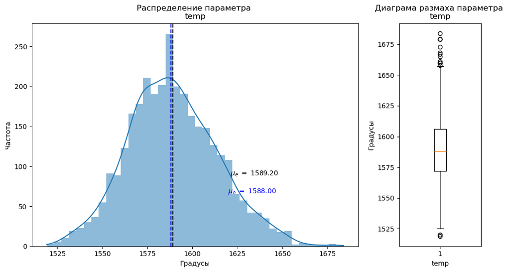

```python
plot_hist_and_box(temp[temp['temp'] > 1500].groupby('key')['temp'].first(), bins=40)
```

`Последняя температура`:

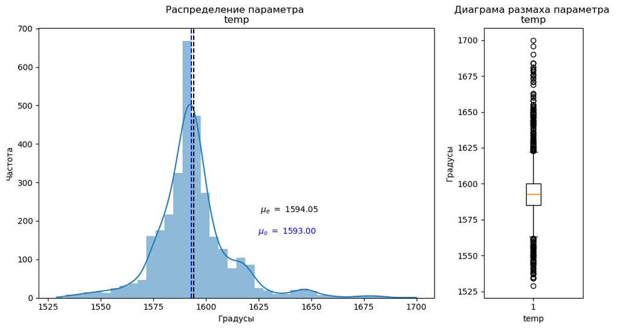

```python
plot_hist_and_box(temp[temp['temp'] > 1500].groupby('key')['temp'].last(), bins=40)
```

#### Распределение количества измерений температуры

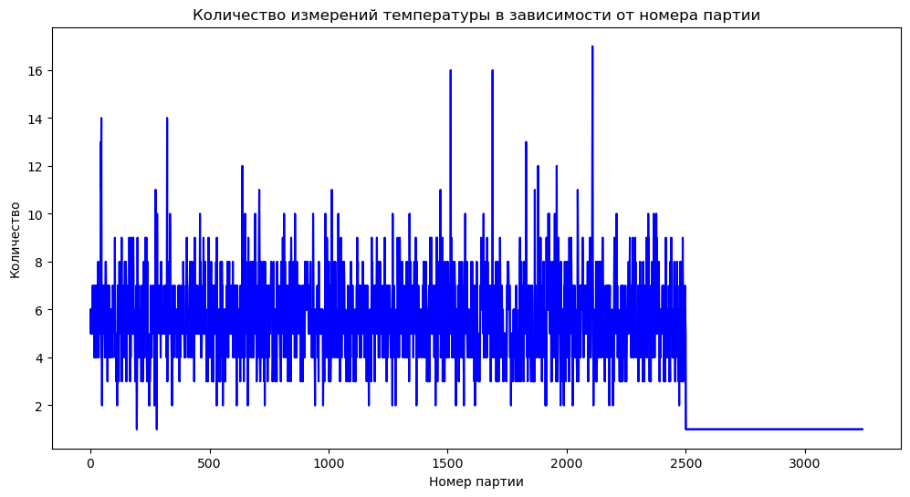

```python
plt.figure(figsize=figsize)
plt.plot(temp['key'].unique(), temp.dropna().groupby('key').count(), color='b')
plt.title('Количество измерений температуры в зависимости от номера партии')
plt.ylabel('Количество'); plt.xlabel('Номер партии');
```

Замечено, что на партиях с ключом больше 2500 нет повторных измерений температуры. Если это последние измерения (целевой параметр), то эти данные использовать нельзя.

```python
temp[temp['key'] >= 2500].fillna(0).groupby('key')['temp'].last().sum()
```

```
0.0
```

Так и есть, сумма всех последних значений параметра `Температура` после партии с ключом 2500 (включительно) равна нулю, что означает, что целевой показатель в этих партиях отсутствует. Данные партии придется удалить при предобработке.

### Анализ `data_wire_new.csv` и `data_wire_time_new.csv`

```python
wire.head()
```

|  | key | wire_1 | wire_2 | wire_3 | wire_4 | wire_5 | wire_6 | wire_7 | wire_8 | wire_9 |
| --- | --- | --- | --- | --- | --- | --- | --- | --- | --- | --- |
| 0 | 1 | 60.059998 | NaN | NaN | NaN | NaN | NaN | NaN | NaN | NaN |
| 1 | 2 | 96.052315 | NaN | NaN | NaN | NaN | NaN | NaN | NaN | NaN |
| 2 | 3 | 91.160157 | NaN | NaN | NaN | NaN | NaN | NaN | NaN | NaN |
| 3 | 4 | 89.063515 | NaN | NaN | NaN | NaN | NaN | NaN | NaN | NaN |
| 4 | 5 | 89.238236 | 9.11456 | NaN | NaN | NaN | NaN | NaN | NaN | NaN |

```python
wire_time.head()
```

|  | key | wire_1 | wire_2 | wire_3 | wire_4 | wire_5 | wire_6 | wire_7 | wire_8 | wire_9 |
| --- | --- | --- | --- | --- | --- | --- | --- | --- | --- | --- |
| 0 | 1 | 2019-05-03 11:06:19 | NaN | NaN | NaN | NaN | NaN | NaN | NaN | NaN |
| 1 | 2 | 2019-05-03 11:36:50 | NaN | NaN | NaN | NaN | NaN | NaN | NaN | NaN |
| 2 | 3 | 2019-05-03 12:11:46 | NaN | NaN | NaN | NaN | NaN | NaN | NaN | NaN |
| 3 | 4 | 2019-05-03 12:43:22 | NaN | NaN | NaN | NaN | NaN | NaN | NaN | NaN |
| 4 | 5 | 2019-05-03 13:20:44 | 2019-05-03 13:15:34 | NaN | NaN | NaN | NaN | NaN | NaN | NaN |

```python
wire.info()
```

```
<class 'pandas.core.frame.DataFrame'>
RangeIndex: 3081 entries, 0 to 3080
Data columns (total 10 columns):
 #   Column  Non-Null Count  Dtype
---  ------  --------------  -----
 0   key     3081 non-null   int64
 1   wire_1  3055 non-null   float64
 2   wire_2  1079 non-null   float64
 3   wire_3  63 non-null     float64
 4   wire_4  14 non-null     float64
 5   wire_5  1 non-null      float64
 6   wire_6  73 non-null     float64
 7   wire_7  11 non-null     float64
 8   wire_8  19 non-null     float64
 9   wire_9  29 non-null     float64
dtypes: float64(9), int64(1)
memory usage: 240.8 KB
```

```python
wire_time.info()
```

```
<class 'pandas.core.frame.DataFrame'>
RangeIndex: 3081 entries, 0 to 3080
Data columns (total 10 columns):
 #   Column  Non-Null Count  Dtype
---  ------  --------------  -----
 0   key     3081 non-null   int64
 1   wire_1  3055 non-null   object
 2   wire_2  1079 non-null   object
 3   wire_3  63 non-null     object
 4   wire_4  14 non-null     object
 5   wire_5  1 non-null      object
 6   wire_6  73 non-null     object
 7   wire_7  11 non-null     object
 8   wire_8  19 non-null     object
 9   wire_9  29 non-null     object
dtypes: int64(1), object(9)
memory usage: 240.8+ KB
```

```python
wire.describe()
```

|  | key | wire_1 | wire_2 | wire_3 | wire_4 | wire_5 | wire_6 | wire_7 | wire_8 | wire_9 |
| --- | --- | --- | --- | --- | --- | --- | --- | --- | --- | --- |
| count | 3081.000000 | 3055.000000 | 1079.000000 | 63.000000 | 14.000000 | 1.000 | 73.000000 | 11.000000 | 19.000000 | 29.000000 |
| mean | 1623.426485 | 100.895853 | 50.577323 | 189.482681 | 57.442841 | 15.132 | 48.016974 | 10.039007 | 53.625193 | 34.155752 |
| std | 932.996726 | 42.012518 | 39.320216 | 99.513444 | 28.824667 | NaN | 33.919845 | 8.610584 | 16.881728 | 19.931616 |
| min | 1.000000 | 1.918800 | 0.030160 | 0.144144 | 24.148801 | 15.132 | 0.034320 | 0.234208 | 45.076721 | 4.622800 |
| 25% | 823.000000 | 72.115684 | 20.193680 | 95.135044 | 40.807002 | 15.132 | 25.053600 | 6.762756 | 46.094879 | 22.058401 |
| 50% | 1619.000000 | 100.158234 | 40.142956 | 235.194977 | 45.234282 | 15.132 | 42.076324 | 9.017009 | 46.279999 | 30.066399 |
| 75% | 2434.000000 | 126.060483 | 70.227558 | 276.252014 | 76.124619 | 15.132 | 64.212723 | 11.886057 | 48.089603 | 43.862003 |
| max | 3241.000000 | 330.314424 | 282.780152 | 385.008668 | 113.231044 | 15.132 | 180.454575 | 32.847674 | 102.762401 | 90.053604 |

Для `Wire 5` существует всего одно наблюдение, его лучше удалить совсем.

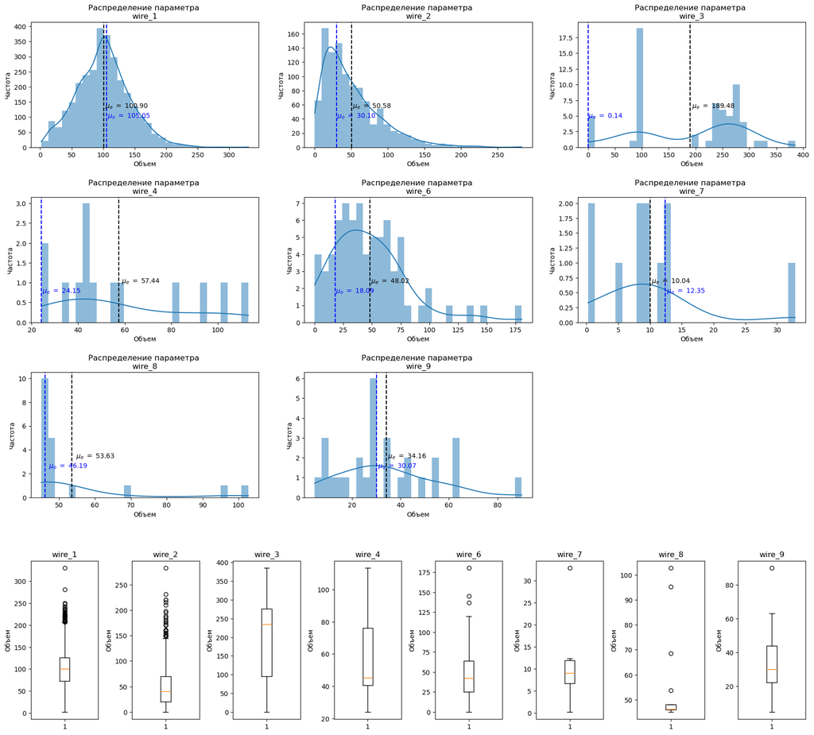

```python
plot_hists_and_boxes(wire.drop(['key', 'wire_5'], axis=1),
                       hist_grid_shape=(3, 3), box_grid_shape=(1, 8), bins=30, density=False)
```

Все проволочные материалы, кроме `wire_3` и `wire_5` распределены одномодально с правой асимметрией. `wire_3` распределена двумодально, где правое распределение более "массивно", сложно судить о том, что здесь является выбросом. Распределение не имеет какой-то четкой формы. Выбросы повторяют формы распределений и скорее всего не являются ошибками.

Сложно судить о том, что здесь является выбросом. Распределение не имеет какой-то четкой формы.

Корректирую тип дат:

```python
wire_time[wire_time.columns[1:]] = pd.to_datetime(wire_time[wire_time.columns[1:]].stack()).unstack()
```

### Анализ сгенерированных признаков

#### Генерация новых признаков и их анализ

#### Распределение `Времени нагрева`

Добавляю новый признак - `Время нагрева` (разность между концом и началом нагрева)

```python
arc['heating_time'] = (arc['heating_stop'] - arc['heating_start']).apply(lambda x: x.total_seconds())
```

```python
arc['work'] = arc['heating_time'] * arc['active_power']
```

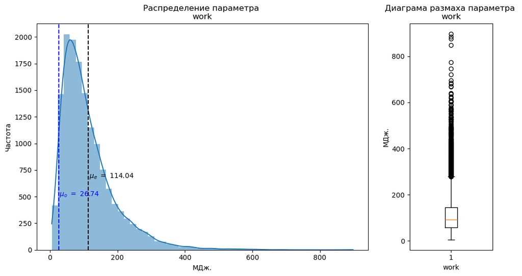

```python
plot_hist_and_box(arc['work'])
```

Достаю признаки из `temp` с привязкой к одному ключу:

```python
temp
```

|  | key | measure_time | temp |
| --- | --- | --- | --- |
| 0 | 1 | 2019-05-03 11:02:04 | 1571.0 |
| 1 | 1 | 2019-05-03 11:07:18 | 1604.0 |
| 2 | 1 | 2019-05-03 11:11:34 | 1618.0 |
| 3 | 1 | 2019-05-03 11:18:04 | 1601.0 |
| 4 | 1 | 2019-05-03 11:25:59 | 1606.0 |
| ... | ... | ... | ... |
| 18087 | 3241 | 2019-09-06 16:55:01 | NaN |
| 18088 | 3241 | 2019-09-06 17:06:38 | NaN |
| 18089 | 3241 | 2019-09-06 17:21:48 | NaN |
| 18090 | 3241 | 2019-09-06 17:24:44 | NaN |
| 18091 | 3241 | 2019-09-06 17:30:05 | NaN |

18092 rows × 3 columns

```python
temp_new = pd.DataFrame(data={
    'first_temp': temp.groupby('key')['temp'].first(),
    'last_temp': temp.groupby('key')['temp'].last(),
    'total_measure_period': (temp.groupby('key')['measure_time'].last() -
                             temp.groupby('key')['measure_time'].first()).apply(lambda x: x.total_seconds())})
temp_new
```

| key | first_temp | last_temp | total_measure_period |
| --- | --- | --- | --- |
| 1 | 1571.0 | 1613.0 | 1714.0 |
| 2 | 1581.0 | 1602.0 | 1265.0 |
| 3 | 1596.0 | 1599.0 | 1753.0 |
| 4 | 1601.0 | 1625.0 | 1220.0 |
| 5 | 1576.0 | 1602.0 | 1536.0 |
| ... | ... | ... | ... |
| 3237 | 1569.0 | 1569.0 | 1470.0 |
| 3238 | 1584.0 | 1584.0 | 1102.0 |
| 3239 | 1598.0 | 1598.0 | 3185.0 |
| 3240 | 1617.0 | 1617.0 | 4205.0 |
| 3241 | 1586.0 | 1586.0 | 2470.0 |

3216 rows × 3 columns

```python
arc
```

|  | key | heating_start | heating_stop | active_power | reactive_power | heating_time | work |
| --- | --- | --- | --- | --- | --- | --- | --- |
| 0 | 1 | 2019-05-03 11:02:14 | 2019-05-03 11:06:02 | 0.305130 | 0.211253 | 228.0 | 69.569640 |
| 1 | 1 | 2019-05-03 11:07:28 | 2019-05-03 11:10:33 | 0.765658 | 0.477438 | 185.0 | 141.646730 |
| 2 | 1 | 2019-05-03 11:11:44 | 2019-05-03 11:14:36 | 0.580313 | 0.430460 | 172.0 | 99.813836 |
| 3 | 1 | 2019-05-03 11:18:14 | 2019-05-03 11:24:19 | 0.518496 | 0.379979 | 365.0 | 189.251040 |
| 4 | 1 | 2019-05-03 11:26:09 | 2019-05-03 11:28:37 | 0.867133 | 0.643691 | 148.0 | 128.335684 |
| ... | ... | ... | ... | ... | ... | ... | ... |
| 14871 | 3241 | 2019-09-06 16:49:05 | 2019-09-06 16:51:42 | 0.439735 | 0.299579 | 157.0 | 69.038395 |
| 14872 | 3241 | 2019-09-06 16:55:11 | 2019-09-06 16:58:11 | 0.646498 | 0.458240 | 180.0 | 116.369640 |
| 14873 | 3241 | 2019-09-06 17:06:48 | 2019-09-06 17:09:52 | 1.039726 | 0.769302 | 184.0 | 191.309584 |
| 14874 | 3241 | 2019-09-06 17:21:58 | 2019-09-06 17:22:55 | 0.530267 | 0.361543 | 57.0 | 30.225219 |
| 14875 | 3241 | 2019-09-06 17:24:54 | 2019-09-06 17:26:15 | 0.389057 | 0.251347 | 81.0 | 31.513617 |

14876 rows × 7 columns

Агрегирую данные плавки:

```python
arc_new = pd.DataFrame(data={
    'heating_rounds': arc.groupby('key')['key'].count(),
    'mean_heating_time': arc.groupby('key')['heating_time'].mean(),
    'total_heating_time': arc.groupby('key')['heating_time'].sum(),
    'heating_period': arc.groupby('key')['heating_time'].max() - arc.groupby('key')['heating_time'].min(),
    'mean_active_power': arc.groupby('key')['active_power'].mean(),
    'mean_reactive_power': arc.groupby('key')['reactive_power'].mean(),
    'total_active_power': arc.groupby('key')['active_power'].sum(),
    'total_reactive_power': arc.groupby('key')['reactive_power'].sum(),
    'full_power': (arc.groupby('key')['active_power'].mean()**2 +
                   arc.groupby('key')['reactive_power'].mean()**2)**0.5,
    'total_work': arc.groupby('key')['work'].sum()


})

arc_new
```

| key | heating_rounds | mean_heating_time | total_heating_time | heating_period | mean_active_power | mean_reactive_power | total_active_power | total_reactive_power | full_power | total_work |
| --- | --- | --- | --- | --- | --- | --- | --- | --- | --- | --- |
| 1 | 5 | 219.60 | 1098.0 | 217.0 | 0.607346 | 0.428564 | 3.036730 | 2.142821 | 0.743328 | 628.616930 |
| 2 | 4 | 202.75 | 811.0 | 212.0 | 0.534852 | 0.363339 | 2.139408 | 1.453357 | 0.646593 | 395.281800 |
| 3 | 5 | 131.00 | 655.0 | 215.0 | 0.812728 | 0.587491 | 4.063641 | 2.937457 | 1.002833 | 581.774624 |
| 4 | 4 | 185.25 | 741.0 | 179.0 | 0.676622 | 0.514248 | 2.706489 | 2.056992 | 0.849864 | 543.710274 |
| 5 | 4 | 217.25 | 869.0 | 344.0 | 0.563238 | 0.421998 | 2.252950 | 1.687991 | 0.703789 | 412.180480 |
| ... | ... | ... | ... | ... | ... | ... | ... | ... | ... | ... |
| 3237 | 5 | 181.80 | 909.0 | 123.0 | 0.508374 | 0.405083 | 2.541872 | 2.025417 | 0.650029 | 493.152191 |
| 3238 | 3 | 182.00 | 546.0 | 154.0 | 0.458274 | 0.346034 | 1.374821 | 1.038103 | 0.574243 | 229.390861 |
| 3239 | 8 | 152.00 | 1216.0 | 241.0 | 0.606001 | 0.442693 | 4.848005 | 3.541541 | 0.750476 | 751.674870 |
| 3240 | 5 | 167.80 | 839.0 | 153.0 | 0.663536 | 0.474710 | 3.317679 | 2.373552 | 0.815861 | 530.736187 |
| 3241 | 5 | 131.80 | 659.0 | 127.0 | 0.609057 | 0.428002 | 3.045283 | 2.140011 | 0.744403 | 438.456455 |

3214 rows × 10 columns

#### Распределение новых признаков

```python
arc['heating_time'].describe()
```

```
count    14876.000000
mean       171.670946
std         98.186803
min         11.000000
25%        107.000000
50%        147.000000
75%        214.000000
max        907.000000
Name: heating_time, dtype: float64
```

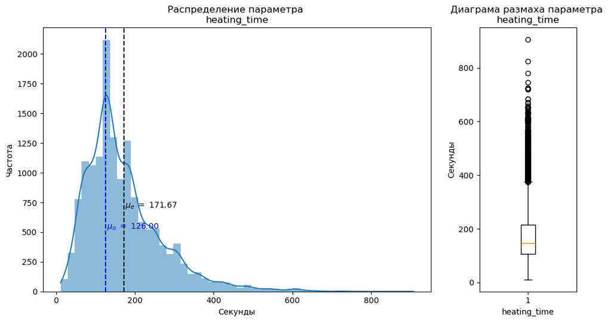

```python
plot_hist_and_box(arc['heating_time'])
```

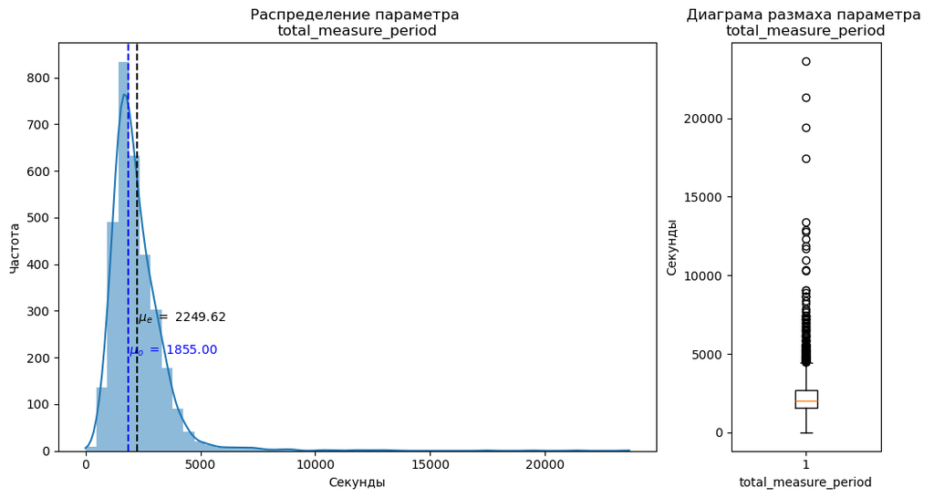

```python
plot_hist_and_box(temp_new['total_measure_period'])
```

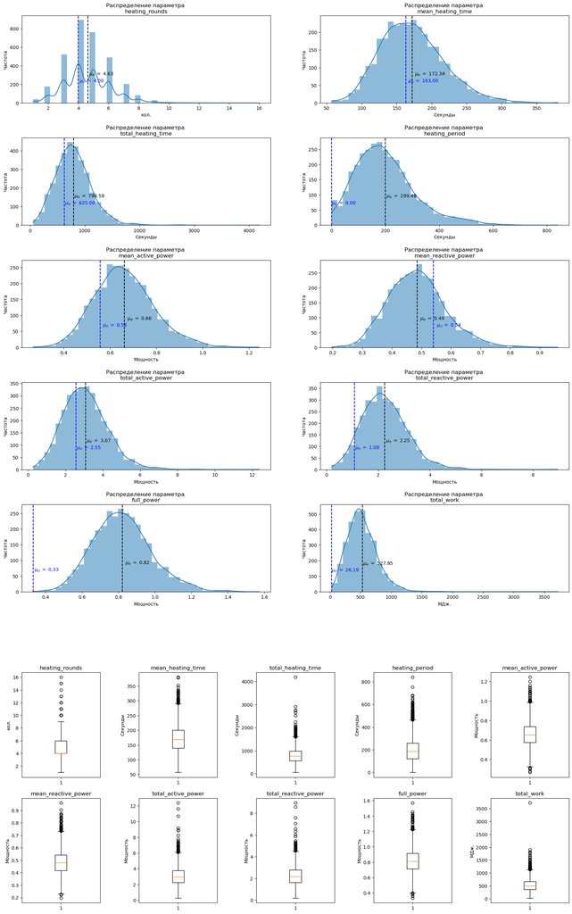

```python
plot_hists_and_boxes(arc_new,
                     hist_grid_shape=(5, 2), box_grid_shape=(2, 5), bins=40)
```

Правоасимметричное распределение, среднее количество циклов нагрева - 4,63, максимальное - 16. Аномалий не найдено. Значения выше 11 похожи на выбросы, но продолжают форму распределения.

В распределениях отмечена сильная правая асимметрия признака `Общий период измерений` и небольшая правая асимметрия во всех остальных, то есть все остальные признаки распределены близко к нормальному. Однако у всех новых признаков длинные правые хвосты. На диаграммах размаха заметно, что в хвостах имеются выбросы, которые будут удалены ниже.

### Выводы, знакомство с данными и исследовательский анализ

В данных имеются аномалии и пропуски:

- Аномальный минимум значения признака `Реактивная мощность` по ключу `2116`. Скорее всего это ошибка в данных.
- Значения температуры (меньше 1500).
- Обнаружены пропуски в датафреймах `bulk`, `bulk_time`, `temp`, `wire`, `wire_time`.
- В датафреймах обнаружено несоответсвие типов данных для некоторых столбцов, что будет исправлено на этапе предобработки.

## Предобработка данных

### Подготовка и сведение признаков

Удаляю единственные замеры температуры:

```python
temp_single = temp['key'].value_counts().index[temp['key'].value_counts() == 1]
temp_single
```

```
Index([195, 279], dtype='int64', name='key')
```

```python
temp = temp[~temp['key'].isin(temp_single)]
```

Дальше понадобятся данные из датафреймов `temp`, `arc`, `bulk`, `wire`, `gas`.

#### Сведение признаков в единую структуру и заполнение пробелов

```python
merged_df = arc_new.merge(temp_new, on='key') \
    .merge(bulk.fillna(0), on='key') \
    .merge(wire.fillna(0), on='key') \
    .merge(gas, on='key', how='left').set_index('key').fillna(0)
merged_df.info()
```

```
<class 'pandas.core.frame.DataFrame'>
Index: 3024 entries, 1 to 3241
Data columns (total 38 columns):
 #   Column                Non-Null Count  Dtype
---  ------                --------------  -----
 0   heating_rounds        3024 non-null   int64
 1   mean_heating_time     3024 non-null   float64
 2   total_heating_time    3024 non-null   float64
 3   heating_period        3024 non-null   float64
 4   mean_active_power     3024 non-null   float64
 5   mean_reactive_power   3024 non-null   float64
 6   total_active_power    3024 non-null   float64
 7   total_reactive_power  3024 non-null   float64
 8   full_power            3024 non-null   float64
 9   total_work            3024 non-null   float64
```

[output cut: 30 more lines]

```python
pd.set_option('display.max_columns', 500)
merged_df
```

| key | heating_rounds | mean_heating_time | total_heating_time | heating_period | mean_active_power | mean_reactive_power | total_active_power | total_reactive_power | full_power | total_work | first_temp | last_temp | total_measure_period | bulk_1 | bulk_2 | bulk_3 | bulk_4 | bulk_5 | bulk_6 | bulk_7 | bulk_8 | bulk_9 | bulk_10 | bulk_11 | bulk_12 | bulk_13 | bulk_14 | bulk_15 | wire_1 | … |
| --- | --- | --- | --- | --- | --- | --- | --- | --- | --- | --- | --- | --- | --- | --- | --- | --- | --- | --- | --- | --- | --- | --- | --- | --- | --- | --- | --- | --- | --- | --- |
| 1 | 5 | 219.60 | 1098.0 | 217.0 | 0.607346 | 0.428564 | 3.036730 | 2.142821 | 0.743328 | 628.616930 | 1571.0 | 1613.0 | 1714.0 | 0.0 | 0.0 | 0.0 | 43.0 | 0.0 | 0.0 | 0.0 | 0.0 | 0.0 | 0.0 | 0.0 | 206.0 | 0.0 | 150.0 | 154.0 | 60.059998 | … |
| 2 | 4 | 202.75 | 811.0 | 212.0 | 0.534852 | 0.363339 | 2.139408 | 1.453357 | 0.646593 | 395.281800 | 1581.0 | 1602.0 | 1265.0 | 0.0 | 0.0 | 0.0 | 73.0 | 0.0 | 0.0 | 0.0 | 0.0 | 0.0 | 0.0 | 0.0 | 206.0 | 0.0 | 149.0 | 154.0 | 96.052315 | … |
| 3 | 5 | 131.00 | 655.0 | 215.0 | 0.812728 | 0.587491 | 4.063641 | 2.937457 | 1.002833 | 581.774624 | 1596.0 | 1599.0 | 1753.0 | 0.0 | 0.0 | 0.0 | 34.0 | 0.0 | 0.0 | 0.0 | 0.0 | 0.0 | 0.0 | 0.0 | 205.0 | 0.0 | 152.0 | 153.0 | 91.160157 | … |
| 4 | 4 | 185.25 | 741.0 | 179.0 | 0.676622 | 0.514248 | 2.706489 | 2.056992 | 0.849864 | 543.710274 | 1601.0 | 1625.0 | 1220.0 | 0.0 | 0.0 | 0.0 | 81.0 | 0.0 | 0.0 | 0.0 | 0.0 | 0.0 | 0.0 | 0.0 | 207.0 | 0.0 | 153.0 | 154.0 | 89.063515 | … |
| 5 | 4 | 217.25 | 869.0 | 344.0 | 0.563238 | 0.421998 | 2.252950 | 1.687991 | 0.703789 | 412.180480 | 1576.0 | 1602.0 | 1536.0 | 0.0 | 0.0 | 0.0 | 78.0 | 0.0 | 0.0 | 0.0 | 0.0 | 0.0 | 0.0 | 0.0 | 203.0 | 0.0 | 151.0 | 152.0 | 89.238236 | … |
| ... | ... | ... | ... | ... | ... | ... | ... | ... | ... | ... | ... | ... | ... | ... | ... | ... | ... | ... | ... | ... | ... | ... | ... | ... | ... | ... | ... | ... | ... | … |
| 3237 | 5 | 181.80 | 909.0 | 123.0 | 0.508374 | 0.405083 | 2.541872 | 2.025417 | 0.650029 | 493.152191 | 1569.0 | 1569.0 | 1470.0 | 0.0 | 0.0 | 170.0 | 0.0 | 0.0 | 0.0 | 0.0 | 0.0 | 0.0 | 0.0 | 0.0 | 252.0 | 0.0 | 130.0 | 206.0 | 38.088959 | … |
| 3238 | 3 | 182.00 | 546.0 | 154.0 | 0.458274 | 0.346034 | 1.374821 | 1.038103 | 0.574243 | 229.390861 | 1584.0 | 1584.0 | 1102.0 | 0.0 | 0.0 | 126.0 | 0.0 | 0.0 | 0.0 | 0.0 | 0.0 | 0.0 | 0.0 | 0.0 | 254.0 | 0.0 | 108.0 | 106.0 | 56.128799 | … |
| 3239 | 8 | 152.00 | 1216.0 | 241.0 | 0.606001 | 0.442693 | 4.848005 | 3.541541 | 0.750476 | 751.674870 | 1598.0 | 1598.0 | 3185.0 | 0.0 | 0.0 | 0.0 | 0.0 | 0.0 | 114.0 | 0.0 | 0.0 | 0.0 | 0.0 | 0.0 | 158.0 | 0.0 | 270.0 | 88.0 | 143.357761 | … |
| 3240 | 5 | 167.80 | 839.0 | 153.0 | 0.663536 | 0.474710 | 3.317679 | 2.373552 | 0.815861 | 530.736187 | 1617.0 | 1617.0 | 4205.0 | 0.0 | 0.0 | 0.0 | 0.0 | 0.0 | 26.0 | 0.0 | 0.0 | 0.0 | 0.0 | 0.0 | 0.0 | 0.0 | 192.0 | 54.0 | 34.070400 | … |
| 3241 | 5 | 131.80 | 659.0 | 127.0 | 0.609057 | 0.428002 | 3.045283 | 2.140011 | 0.744403 | 438.456455 | 1586.0 | 1586.0 | 2470.0 | 0.0 | 0.0 | 0.0 | 0.0 | 0.0 | 0.0 | 0.0 | 0.0 | 0.0 | 0.0 | 0.0 | 0.0 | 0.0 | 180.0 | 52.0 | 63.117595 | … |

3024 rows × 38 columns

```python
merged_df.describe().T
```

|  | count | mean | std | min | 25% | 50% | 75% | max |
| --- | --- | --- | --- | --- | --- | --- | --- | --- |
| heating_rounds | 3024.0 | 4.699074 | 1.603849 | 1.000000 | 4.000000 | 5.000000 | 6.000000 | 16.000000 |
| mean_heating_time | 3024.0 | 171.163003 | 44.051408 | 57.000000 | 139.787500 | 167.750000 | 198.400000 | 378.000000 |
| total_heating_time | 3024.0 | 801.734127 | 331.499780 | 57.000000 | 577.500000 | 776.000000 | 987.000000 | 4189.000000 |
| heating_period | 3024.0 | 198.929233 | 111.876632 | 0.000000 | 121.000000 | 184.000000 | 255.000000 | 840.000000 |
| mean_active_power | 3024.0 | 0.661745 | 0.127055 | 0.267676 | 0.574171 | 0.654259 | 0.738061 | 1.243889 |
| mean_reactive_power | 3024.0 | 0.486369 | 0.096710 | 0.196228 | 0.418144 | 0.481886 | 0.543080 | 0.960763 |
| total_active_power | 3024.0 | 3.115444 | 1.206570 | 0.267676 | 2.290962 | 3.023124 | 3.832095 | 12.375636 |
| total_reactive_power | 3024.0 | 2.289961 | 0.892908 | 0.196228 | 1.668360 | 2.215952 | 2.818647 | 8.949049 |
| full_power | 3024.0 | 0.821497 | 0.158426 | 0.331897 | 0.711919 | 0.812730 | 0.914330 | 1.571727 |
| total_work | 3024.0 | 533.033797 | 248.704485 | 26.187544 | 366.352167 | 502.862856 | 672.923190 | 3718.054401 |
| first_temp | 3024.0 | 1586.770833 | 28.096192 | 1191.000000 | 1571.000000 | 1587.000000 | 1603.000000 | 1660.000000 |
| last_temp | 3024.0 | 1591.894841 | 16.639456 | 1204.000000 | 1585.000000 | 1592.000000 | 1599.000000 | 1653.000000 |
| total_measure_period | 3024.0 | 2292.637566 | 1327.129317 | 339.000000 | 1569.750000 | 2026.000000 | 2740.250000 | 23674.000000 |
| bulk_1 | 3024.0 | 3.270172 | 12.058660 | 0.000000 | 0.000000 | 0.000000 | 0.000000 | 185.000000 |
| bulk_2 | 3024.0 | 1.840939 | 21.580585 | 0.000000 | 0.000000 | 0.000000 | 0.000000 | 325.000000 |
| bulk_3 | 3024.0 | 48.686839 | 74.939933 | 0.000000 | 0.000000 | 0.000000 | 82.000000 | 454.000000 |
| bulk_4 | 3024.0 | 34.970899 | 56.627035 | 0.000000 | 0.000000 | 0.000000 | 72.250000 | 281.000000 |
| bulk_5 | 3024.0 | 2.725198 | 21.272461 | 0.000000 | 0.000000 | 0.000000 | 0.000000 | 603.000000 |
| bulk_6 | 3024.0 | 22.481151 | 56.173538 | 0.000000 | 0.000000 | 0.000000 | 0.000000 | 503.000000 |
| bulk_7 | 3024.0 | 2.510913 | 32.480757 | 0.000000 | 0.000000 | 0.000000 | 0.000000 | 772.000000 |
| bulk_8 | 3024.0 | 0.016204 | 0.891056 | 0.000000 | 0.000000 | 0.000000 | 0.000000 | 49.000000 |
| bulk_9 | 3024.0 | 0.479497 | 6.259752 | 0.000000 | 0.000000 | 0.000000 | 0.000000 | 147.000000 |
| bulk_10 | 3024.0 | 4.847222 | 20.485163 | 0.000000 | 0.000000 | 0.000000 | 0.000000 | 159.000000 |
| bulk_11 | 3024.0 | 4.496362 | 23.075735 | 0.000000 | 0.000000 | 0.000000 | 0.000000 | 313.000000 |
| bulk_12 | 3024.0 | 203.324405 | 152.207617 | 0.000000 | 105.000000 | 206.000000 | 263.000000 | 1849.000000 |
| bulk_13 | 3024.0 | 1.078042 | 14.355922 | 0.000000 | 0.000000 | 0.000000 | 0.000000 | 305.000000 |
| bulk_14 | 3024.0 | 153.079696 | 80.843473 | 0.000000 | 104.000000 | 148.000000 | 202.000000 | 636.000000 |
| bulk_15 | 3024.0 | 118.724868 | 83.377105 | 0.000000 | 0.000000 | 106.000000 | 204.000000 | 405.000000 |
| wire_1 | 3024.0 | 100.299023 | 42.741829 | 0.000000 | 71.348941 | 100.151993 | 125.820243 | 330.314424 |
| wire_2 | 3024.0 | 17.544388 | 33.298348 | 0.000000 | 0.000000 | 0.000000 | 23.153520 | 282.780152 |
| wire_3 | 3024.0 | 3.947556 | 30.590127 | 0.000000 | 0.000000 | 0.000000 | 0.000000 | 385.008668 |
| wire_4 | 3024.0 | 0.265939 | 4.334006 | 0.000000 | 0.000000 | 0.000000 | 0.000000 | 113.231044 |
| wire_5 | 3024.0 | 0.005004 | 0.275173 | 0.000000 | 0.000000 | 0.000000 | 0.000000 | 15.132000 |
| wire_6 | 3024.0 | 1.159140 | 9.040797 | 0.000000 | 0.000000 | 0.000000 | 0.000000 | 180.454575 |
| wire_7 | 3024.0 | 0.036518 | 0.781439 | 0.000000 | 0.000000 | 0.000000 | 0.000000 | 32.847674 |
| wire_8 | 3024.0 | 0.336931 | 4.433660 | 0.000000 | 0.000000 | 0.000000 | 0.000000 | 102.762401 |
| wire_9 | 3024.0 | 0.246795 | 3.039308 | 0.000000 | 0.000000 | 0.000000 | 0.000000 | 62.025600 |
| gas_vol | 3024.0 | 11.294958 | 6.238107 | 0.000000 | 7.265603 | 10.014234 | 14.072690 | 77.995040 |

#### Удаление выявленных в анализе аномалий

```python
# Пункт 2.2 недостаточно данных по Bulk 8
merged_df = merged_df.drop('bulk_8', axis=1)

# Пункт 2.4, удаляются все значения температуры меньше 1500
merged_df = merged_df.drop(temp_keys_to_del)

# Пункт 2.5, для плавок после ключа 2500 нет целевого признака
merged_df = merged_df[merged_df.index < 2500]

# Пункт 2.6 недостаточно данных по Wire 5
merged_df = merged_df.drop('wire_5', axis=1)
```

#### Оптимизация типов данных по потреблению памяти

```python
int8_cols = ['heating_rounds']
int16_cols = ['mean_heating_time', 'total_heating_time', 'first_temp', 'last_temp',
              'total_measure_period','bulk_1', 'bulk_2','bulk_3', 'bulk_4', 'bulk_5', 'bulk_6', 'bulk_7',
              'bulk_9', 'bulk_10', 'bulk_11', 'bulk_12', 'bulk_13', 'bulk_14', 'bulk_15', 'heating_period']
float_cols = merged_df.loc[:, ~merged_df.columns.isin(int8_cols+int16_cols)].columns.tolist()

merged_df[int8_cols] = merged_df[int8_cols].astype('int8')
merged_df[int16_cols] = merged_df[int16_cols].astype('int16')
merged_df[float_cols] = merged_df[float_cols].astype('float32')

merged_df.info()
```

```
<class 'pandas.core.frame.DataFrame'>
Index: 2327 entries, 1 to 2499
Data columns (total 36 columns):
 #   Column                Non-Null Count  Dtype
---  ------                --------------  -----
 0   heating_rounds        2327 non-null   int8
 1   mean_heating_time     2327 non-null   int16
 2   total_heating_time    2327 non-null   int16
 3   heating_period        2327 non-null   int16
 4   mean_active_power     2327 non-null   float32
 5   mean_reactive_power   2327 non-null   float32
 6   total_active_power    2327 non-null   float32
 7   total_reactive_power  2327 non-null   float32
 8   full_power            2327 non-null   float32
 9   total_work            2327 non-null   float32
```

[output cut: 28 more lines]

### Корреляционный анализ взаимозависимости признаков

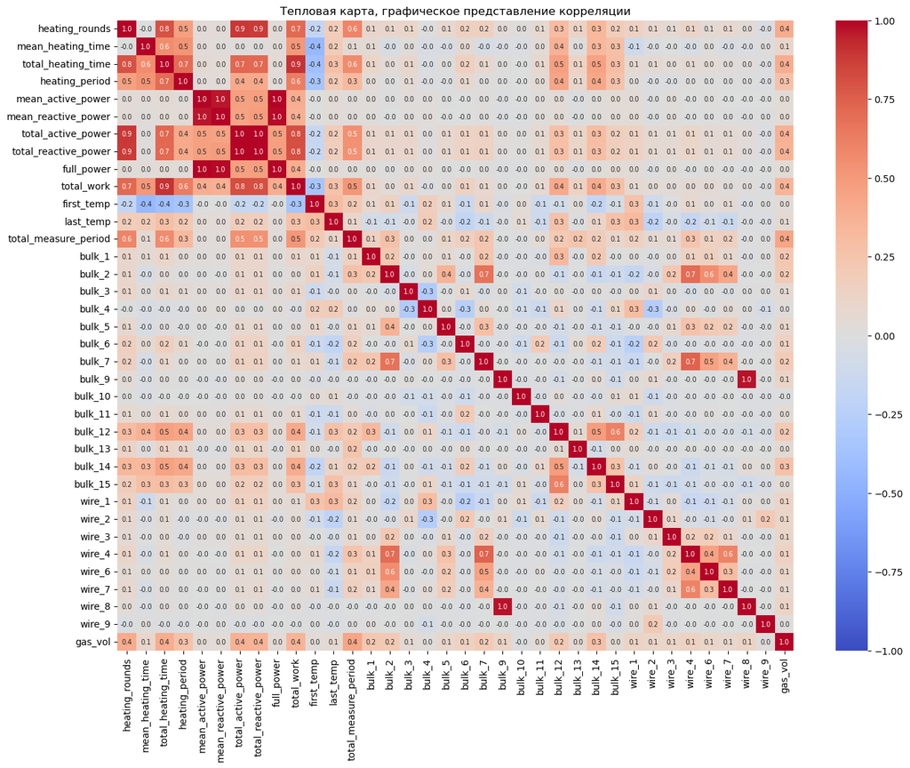

```python
plt.figure(figsize=(16, 12))
sns.heatmap(merged_df.corr(),
    cmap='coolwarm',
    vmin=-1.0, vmax=1.0,
    annot=True, fmt='0,.1f',
    annot_kws={'size': 'x-small'}
    ).set_title('Тепловая карта, графическое представление корреляции');
```

Абсолютно положительно скоррелированы показатели `Активной мощности` и `Реактивной мощности` (средние и суммарные), для борьбы с мультиколлинеарностью один из них имеет смысл удалить для линейных моделей. То же самое касается материалов `Bulk 9` и `Wire 8`.

Сильно скоррелированы показатели `Количества циклов нагрева` и `Суммарной активной мощности`, но корреляция не абсолютна, так что негативные эффекты мультиколлинеарности могут не возникнуть.

### Подготовка обучающей и тестовой выборок

```python
target_col = 'last_temp'
features = merged_df.drop(target_col, axis=1)
target = merged_df[target_col]

features_train, features_test, target_train, target_test = train_test_split(
        features, target, test_size=test_size, random_state=random_state)
```

```python
features_train
```

| key | heating_rounds | mean_heating_time | total_heating_time | heating_period | mean_active_power | mean_reactive_power | total_active_power | total_reactive_power | full_power | total_work | first_temp | total_measure_period | bulk_1 | bulk_2 | bulk_3 | bulk_4 | bulk_5 | bulk_6 | bulk_7 | bulk_9 | bulk_10 | bulk_11 | bulk_12 | bulk_13 | bulk_14 | bulk_15 | wire_1 | wire_2 | wire_3 | … |
| --- | --- | --- | --- | --- | --- | --- | --- | --- | --- | --- | --- | --- | --- | --- | --- | --- | --- | --- | --- | --- | --- | --- | --- | --- | --- | --- | --- | --- | --- | --- |
| 1849 | 3 | 143 | 430 | 33 | 0.774874 | 0.552433 | 2.324621 | 1.657299 | 0.951636 | 344.143768 | 1609 | 1349 | 0 | 0 | 0 | 141 | 0 | 0 | 0 | 0 | 0 | 0 | 206 | 0 | 99 | 203 | 123.177597 | 0.000000 | 0.000000 | … |
| 1111 | 4 | 197 | 788 | 138 | 0.670459 | 0.512564 | 2.681835 | 2.050256 | 0.843941 | 505.856689 | 1562 | 1297 | 0 | 0 | 0 | 0 | 0 | 0 | 0 | 0 | 0 | 0 | 256 | 0 | 99 | 203 | 74.131195 | 53.172081 | 231.014801 | … |
| 2121 | 3 | 96 | 290 | 52 | 0.481608 | 0.348161 | 1.444824 | 1.044483 | 0.594275 | 139.927979 | 1580 | 1578 | 0 | 0 | 0 | 0 | 0 | 181 | 0 | 0 | 0 | 0 | 0 | 0 | 139 | 0 | 80.152794 | 0.000000 | 0.000000 | … |
| 533 | 3 | 107 | 322 | 41 | 0.477646 | 0.333938 | 1.432939 | 1.001814 | 0.582804 | 155.360535 | 1614 | 1579 | 0 | 0 | 0 | 0 | 0 | 0 | 0 | 0 | 0 | 0 | 203 | 0 | 133 | 106 | 150.274796 | 15.170480 | 0.000000 | … |
| 149 | 7 | 135 | 949 | 239 | 0.585550 | 0.424195 | 4.098850 | 2.969367 | 0.723056 | 588.939636 | 1591 | 1981 | 0 | 0 | 0 | 0 | 0 | 321 | 0 | 0 | 0 | 25 | 0 | 0 | 105 | 203 | 92.033760 | 0.000000 | 0.000000 | … |
| ... | ... | ... | ... | ... | ... | ... | ... | ... | ... | ... | ... | ... | ... | ... | ... | ... | ... | ... | ... | ... | ... | ... | ... | ... | ... | ... | ... | ... | ... | … |
| 1775 | 4 | 127 | 510 | 219 | 0.616655 | 0.462768 | 2.466619 | 1.851071 | 0.770984 | 280.787689 | 1604 | 1744 | 0 | 0 | 21 | 0 | 0 | 0 | 0 | 0 | 0 | 0 | 205 | 0 | 119 | 105 | 145.126801 | 0.000000 | 0.000000 | … |
| 1674 | 4 | 133 | 533 | 159 | 0.520962 | 0.397713 | 2.083849 | 1.590852 | 0.655421 | 254.669128 | 1586 | 1787 | 0 | 0 | 0 | 0 | 22 | 190 | 0 | 0 | 0 | 0 | 0 | 0 | 201 | 0 | 120.088806 | 73.409439 | 0.000000 | … |
| 2225 | 2 | 189 | 379 | 47 | 0.509652 | 0.359547 | 1.019305 | 0.719093 | 0.623714 | 200.233658 | 1587 | 779 | 0 | 0 | 0 | 0 | 0 | 0 | 0 | 0 | 88 | 0 | 252 | 0 | 129 | 236 | 46.038719 | 0.000000 | 0.000000 | … |
| 2401 | 5 | 154 | 771 | 146 | 0.768460 | 0.538815 | 3.842298 | 2.694075 | 0.938537 | 588.850952 | 1620 | 1946 | 0 | 0 | 0 | 98 | 0 | 0 | 0 | 0 | 0 | 0 | 156 | 0 | 139 | 104 | 102.167519 | 0.000000 | 0.000000 | … |
| 312 | 6 | 253 | 1521 | 608 | 0.737535 | 0.528660 | 4.425207 | 3.171962 | 0.907435 | 1188.894043 | 1579 | 2453 | 0 | 0 | 0 | 0 | 0 | 0 | 0 | 0 | 0 | 0 | 410 | 0 | 253 | 154 | 149.079834 | 0.000000 | 0.000000 | … |

1745 rows × 35 columns

```python
print('Размеры выборок:')
print(f'Обучающая: {features_train.shape}, {target_train.shape}')
print(f'Тестовая: {features_test.shape}, {target_test.shape}')
```

```
Размеры выборок:
Обучающая: (1745, 35), (1745,)
Тестовая: (582, 35), (582,)
```

### Удаление выбросов в обучающей выборке

```python
isolation_forest = IsolationForest(n_estimators=2000, random_state=random_state)
estimator = isolation_forest.fit_predict(features_train)
outliers = np.array([True if i == -1 else False for i in estimator])
print("Количество аномалий: ", sum(outliers))
```

```
Количество аномалий:  31
```

```python
isolation_forest.fit(merged_df.drop('last_temp', axis=1))
estimator2 = isolation_forest.predict(features_train)
outliers2 = np.array([True if i == -1 else False for i in estimator2])
print("Количество аномалий: ", sum(outliers2))
```

```
Количество аномалий:  30
```

```python
features_train[outliers2].index
```

```
Index([1269,  928, 1470,  117, 2104,  327,  877,  782, 2105,  119,  638,  813,
       1923, 2107, 2001, 2046,  118, 2106, 1689,  115, 1464, 1513, 1816,  280,
        650, 2472,  114, 2110,  460,   44],
      dtype='int64', name='key')
```

```python
# set(features_train[outliers2].index).intersection(set(keys_to_del))
# estimator3 = isolation_forest.predict(features_test)
# outliers3 = np.array([True if i == -1 else False for i in estimator3])
# print("Количество аномалий: ", sum(outliers3))
# len(set(features_train[outliers].index).intersection(set(features_train[outliers2].index)))
# features_test[outliers3].join(target_test[outliers3])
# sure_keys_to_del = list(set(features_train[outliers2].index).intersection(set(keys_to_del)))
# features_train = features_train.drop(sure_keys_to_del)
# target_train = target_train.drop(sure_keys_to_del)
# features_train = features_train[np.invert(outliers)]
# target_train = target_train[np.invert(outliers)]
```

```python
keys_to_del = features_train.index[
    # Выбросы в сгенерированных признаках:
                     (features_train['heating_rounds'] > 12) |
                     (features_train['total_heating_time'] > 3000) |
                     (features_train['mean_active_power'] > 1.2) |
                     (features_train['mean_reactive_power'] > 0.9) |
                     (features_train['total_active_power'] > 8) |
                     (features_train['total_reactive_power'] > 6) |
                     (features_train['total_work'] > 2000) |
                     (features_train['total_measure_period'] > 15000) |
    # Пункт 2.2, выбросы в распределениях bulk:
                     (features_train['bulk_1'] > 125) |
                     (features_train['bulk_5'] > 350) |
                     (features_train['bulk_6'] > 450) |
                     (features_train['bulk_12'] > 900) |
                     (features_train['bulk_14'] > 500) |
    # Пункт 2.3, выбросы в распределении gas:
                     (features_train['gas_vol'] > 45) |
    # Пункт 2.6, выбросы в распределениях Wire
                     (features_train['wire_1'] > 270) |
                     (features_train['wire_2'] > 250)
]

features_train = features_train.drop(keys_to_del)
target_train = target_train.drop(keys_to_del)
```

```python
keys_to_del
```

```
Index([1269, 117, 641, 1821, 1689, 1464, 1513, 280, 2110, 2497], dtype='int64', name='key')
```

```python
features_train
```

| key | heating_rounds | mean_heating_time | total_heating_time | heating_period | mean_active_power | mean_reactive_power | total_active_power | total_reactive_power | full_power | total_work | first_temp | total_measure_period | bulk_1 | bulk_2 | bulk_3 | bulk_4 | bulk_5 | bulk_6 | bulk_7 | bulk_9 | bulk_10 | bulk_11 | bulk_12 | bulk_13 | bulk_14 | bulk_15 | wire_1 | wire_2 | wire_3 | … |
| --- | --- | --- | --- | --- | --- | --- | --- | --- | --- | --- | --- | --- | --- | --- | --- | --- | --- | --- | --- | --- | --- | --- | --- | --- | --- | --- | --- | --- | --- | --- |
| 1849 | 3 | 143 | 430 | 33 | 0.774874 | 0.552433 | 2.324621 | 1.657299 | 0.951636 | 344.143768 | 1609 | 1349 | 0 | 0 | 0 | 141 | 0 | 0 | 0 | 0 | 0 | 0 | 206 | 0 | 99 | 203 | 123.177597 | 0.000000 | 0.000000 | … |
| 1111 | 4 | 197 | 788 | 138 | 0.670459 | 0.512564 | 2.681835 | 2.050256 | 0.843941 | 505.856689 | 1562 | 1297 | 0 | 0 | 0 | 0 | 0 | 0 | 0 | 0 | 0 | 0 | 256 | 0 | 99 | 203 | 74.131195 | 53.172081 | 231.014801 | … |
| 2121 | 3 | 96 | 290 | 52 | 0.481608 | 0.348161 | 1.444824 | 1.044483 | 0.594275 | 139.927979 | 1580 | 1578 | 0 | 0 | 0 | 0 | 0 | 181 | 0 | 0 | 0 | 0 | 0 | 0 | 139 | 0 | 80.152794 | 0.000000 | 0.000000 | … |
| 533 | 3 | 107 | 322 | 41 | 0.477646 | 0.333938 | 1.432939 | 1.001814 | 0.582804 | 155.360535 | 1614 | 1579 | 0 | 0 | 0 | 0 | 0 | 0 | 0 | 0 | 0 | 0 | 203 | 0 | 133 | 106 | 150.274796 | 15.170480 | 0.000000 | … |
| 149 | 7 | 135 | 949 | 239 | 0.585550 | 0.424195 | 4.098850 | 2.969367 | 0.723056 | 588.939636 | 1591 | 1981 | 0 | 0 | 0 | 0 | 0 | 321 | 0 | 0 | 0 | 25 | 0 | 0 | 105 | 203 | 92.033760 | 0.000000 | 0.000000 | … |
| ... | ... | ... | ... | ... | ... | ... | ... | ... | ... | ... | ... | ... | ... | ... | ... | ... | ... | ... | ... | ... | ... | ... | ... | ... | ... | ... | ... | ... | ... | … |
| 1775 | 4 | 127 | 510 | 219 | 0.616655 | 0.462768 | 2.466619 | 1.851071 | 0.770984 | 280.787689 | 1604 | 1744 | 0 | 0 | 21 | 0 | 0 | 0 | 0 | 0 | 0 | 0 | 205 | 0 | 119 | 105 | 145.126801 | 0.000000 | 0.000000 | … |
| 1674 | 4 | 133 | 533 | 159 | 0.520962 | 0.397713 | 2.083849 | 1.590852 | 0.655421 | 254.669128 | 1586 | 1787 | 0 | 0 | 0 | 0 | 22 | 190 | 0 | 0 | 0 | 0 | 0 | 0 | 201 | 0 | 120.088806 | 73.409439 | 0.000000 | … |
| 2225 | 2 | 189 | 379 | 47 | 0.509652 | 0.359547 | 1.019305 | 0.719093 | 0.623714 | 200.233658 | 1587 | 779 | 0 | 0 | 0 | 0 | 0 | 0 | 0 | 0 | 88 | 0 | 252 | 0 | 129 | 236 | 46.038719 | 0.000000 | 0.000000 | … |
| 2401 | 5 | 154 | 771 | 146 | 0.768460 | 0.538815 | 3.842298 | 2.694075 | 0.938537 | 588.850952 | 1620 | 1946 | 0 | 0 | 0 | 98 | 0 | 0 | 0 | 0 | 0 | 0 | 156 | 0 | 139 | 104 | 102.167519 | 0.000000 | 0.000000 | … |
| 312 | 6 | 253 | 1521 | 608 | 0.737535 | 0.528660 | 4.425207 | 3.171962 | 0.907435 | 1188.894043 | 1579 | 2453 | 0 | 0 | 0 | 0 | 0 | 0 | 0 | 0 | 0 | 0 | 410 | 0 | 253 | 154 | 149.079834 | 0.000000 | 0.000000 | … |

1735 rows × 35 columns

### Выводы, предобработка данных

- Из данных были отобраны и созданы признаки для обучения моделей ML, затем итоговый набор признков был сведен в общий датафрейм `merged_df`
- Корреляционный анализ показал крайне сильную линейную взаимосвязь между признаками `Активной мощности` и `Реактивной мощности`. Из-за чего показатель `Реактивной мощности` был удален на этапе обучения линейной регрессии, чтобы избежать проблем с мультиколлинеарностью. Также была замечена сильная линейная взаимосвязь между признаками `Количесто циклов нагрева` и `Сумарными активными/реактивными мощностями`
- Данные были разделены на обучающую и тестовую выборки, выделен целевой признак `Последняя температура`.
- Пробелы и выбросы в данных были удалены
- Проведены оптимизация типов данных с целью уменьшения потребления памяти\процессорного времени.

## Обучение моделей

Функция для подбора гиперпараметров и обучения методом Cross Validation:

```python
def finetune(model_name, parameters, features, target, verbose=3, jobs=-1, cv=5, **kwargs):
    '''Фукнция подбора гиперпараметров
    На вход принимает класс модели, решетку гиперпараметров для поиска, признаки и целевой признак
    Возвращает лучшую из обученных моделей, её гиперпараметры и её луший результат по метрике MAE
    '''
    cv = GridSearchCV(model_name(**kwargs), param_grid=parameters, scoring='neg_mean_absolute_error',
                            cv=cv, verbose=verbose, n_jobs=jobs)
    cv.fit(features, target)

    return cv.best_estimator_, cv.best_params_, -cv.best_score_

def print_cv_results(params, metric):
    '''Выводит результаты кросс-валидации на экран'''
    print()
    print(f'Лучшие параметры модели: {params}')
    print(f'(train, CV) лучшее MAE: {metric:.4f} градуса')
    print()
```

### Константная модель - "тупой регрессор" (Baseline)

```python
dummy_r = DummyRegressor(strategy='mean').fit(features_train, target_train)
target_test_pred = dummy_r.predict(features_test)
dummy_r_test_score = mean_absolute_error(target_test, target_test_pred)
print(f'(test) Итоговая MAE для константной модели (mean): {dummy_r_test_score:.2f} градуса')
```

```
(test) Итоговая MAE для константной модели (mean): 8.13 градуса
```

### Линейная модель

```python
#Удаление сильно скоррелированных признаков для предотвращения мультиколлинеарности:
lin_features_train = features_train.drop(['mean_active_power','mean_reactive_power','total_reactive_power'], axis=1)

params = {}

lr_cv_model, lr_cv_params, lr_cv_score = finetune(LinearRegression, params, lin_features_train, target_train)
print_cv_results(lr_cv_params, lr_cv_score)
```

```
Fitting 5 folds for each of 1 candidates, totalling 5 fits

Лучшие параметры модели: {}
(train, CV) лучшее MAE: 5.8498 градуса
```

### Случайный лес

```python
%%time

params = {
    'n_estimators' : [108, 110, 112],
    'min_samples_leaf': [4, 5],
    'min_samples_split': [5, 6]
}

rf_cv_model, rf_cv_params, rf_cv_score = finetune(RandomForestRegressor, params, features_train, target_train,
                                                        random_state=random_state)
print_cv_results(rf_cv_params, rf_cv_score)
```

[output not shown]

[output cut: 96 more lines]

```
[CV 4/5] END min_samples_leaf=4, min_samples_split=5, n_estimators=108;, score=-5.920 total time=   3.8s
[CV 3/5] END min_samples_leaf=4, min_samples_split=5, n_estimators=110;, score=-6.131 total time=   3.8s
[CV 2/5] END min_samples_leaf=4, min_samples_split=5, n_estimators=112;, score=-6.146 total time=   4.4s
[CV 1/5] END min_samples_leaf=4, min_samples_split=6, n_estimators=108;, score=-6.257 total time=   3.4s
[CV 5/5] END min_samples_leaf=4, min_samples_split=6, n_estimators=108;, score=-5.901 total time=   3.3s
[CV 4/5] END min_samples_leaf=4, min_samples_split=6, n_estimators=110;, score=-5.917 total time=   3.6s
[CV 3/5] END min_samples_leaf=4, min_samples_split=6, n_estimators=112;, score=-6.132 total time=   3.7s
[CV 2/5] END min_samples_leaf=5, min_samples_split=5, n_estimators=108;, score=-6.123 total time=   3.6s
[CV 1/5] END min_samples_leaf=5, min_samples_split=5, n_estimators=110;, score=-6.275 total time=   3.4s

Лучшие параметры модели: {'min_samples_leaf': 4, 'min_samples_split': 5, 'n_estimators': 112}
(train, CV) лучшее MAE: 6.0680 градуса

CPU times: user 4.62 s, sys: 173 ms, total: 4.79 s
Wall time: 59.7 s
```

### Градиентный бустинг (LightGBM)

```python
%%time

params = {'learning_rate': [0.9545, 0.0955],
          'num_leaves': [11, 12],
          'max_bin': [159, 160, 161],
          'lambda_l1': [0.56, 0.565],
          'lambda_l2': [0.055, 0.056]
}

lgbm_cv_model, lgbm_cv_params, lgbm_cv_score = finetune(LGBMRegressor, params,
                                       features_train, target_train, random_state=random_state)

print_cv_results(lgbm_cv_params, lgbm_cv_score)
```

[output not shown]

[output cut: 596 more lines]

[output not shown]

### Итоги обучения моделей методом кросс-валидации:

```python
training_stats = pd.DataFrame({
    'Модель': ['Линейная регрессия', 'Случайный лес', 'LightGBM'],
    '(train CV) MAE': [round(x, 2) for x in [lr_cv_score, rf_cv_score, lgbm_cv_score]],
}).set_index('Модель').sort_values(by='(train CV) MAE')

best_model = training_stats.index[0]
```

Сводная таблица с результатами обучения моделий на обучающей выборке методом кросс-валидации по метрике MAE:

```python
training_stats
```

| Модель | (train CV) MAE |
| --- | --- |
| LightGBM | 5.83 |
| Линейная регрессия | 5.85 |
| Случайный лес | 6.07 |

## Тестирование лучшей модели

```python
print(f'Лучшей моделью по метрике MAE оказалась модель {best_model}')
```

```
Лучшей моделью по метрике MAE оказалась модель LightGBM
```

Обучаю лучшую модель на всей обучающей выборке:

```python
models = {'Линейная регрессия': [LinearRegression, lr_cv_params],
          'Случайный лес': [RandomForestRegressor, rf_cv_params],
          'LightGBM': [LGBMRegressor, lgbm_cv_params],}

test_model = models[best_model][0](**models[best_model][1])
test_model.fit(features_train, target_train)
print('Лучшая модель обучена на всей обучающей выборке')
```

```
Лучшая модель обучена на всей обучающей выборке
```

Проверяю лучшую модель на тестовых данных:

```python
pred_test = test_model.predict(features_test)
final_test_mae = mean_absolute_error(target_test, pred_test)

print(f'MAE модели "{best_model}" на тестовых данных составила {final_test_mae:.3f} градуса')
```

```
MAE модели "LightGBM" на тестовых данных составила 5.935 градуса
```

Для сравнения, baseline констатнтная модель показала результат:

```python
print(f'MAE константной модели (mean) на тестовых данных составила: {dummy_r_test_score:.2f} градуса')
```

```
MAE константной модели (mean) на тестовых данных составила: 8.13 градуса
```

## Итоговый вывод

В ходе работы были проанализированы и обработаны предоставленные данные и подготовлена модель машинного обучения, способная на обучающей выборке выдавать прогноз лучше baseline (Dummy Regressor).

Получены следующие результаты на обучающей выборке:

```python
training_stats.sort_values(by='(train CV) MAE')
```

| Модель | (train CV) MAE |
| --- | --- |
| LightGBM | 5.83 |
| Линейная регрессия | 5.85 |
| Случайный лес | 6.07 |

На тестовой выборке:

```python
print(f'MAE модели "{best_model}" на тестовых данных составила {final_test_mae:.3f}')
```

```
MAE модели "LightGBM" на тестовых данных составила 5.935
```

Эти результаты были получены моделью при обучении со следующими гиперпараметрами:

```python
models[best_model][1]
```

```
{'lambda_l1': 0.56,
 'lambda_l2': 0.056,
 'learning_rate': 0.0955,
 'max_bin': 160,
 'num_leaves': 11}
```

На тестовой выборке с помощью лучшей из обученных моделей (градиентный бустинг LightGBM) получено значение метрики итогового $MAE\approx$ 5,935 градуса, что лучше 6,0 по MAE, приведенного в качестве критерия отличной оценки в ТЗ по проекту. Также это решение лучше baseline решения на $\approx$ 2,2 градуса (константная baseline модель - Dummy Regressor - показывает на тестовой выборке результат: $\approx$ 8,13 градуса).

В итоге удалось обучить модель машинного обучения, которая по метрике MAE лучше альтернатив, включая константную baseline модель.

Наиболее важными признаками для прогнозной модели стали: `Первая температура`, `Общее время нагрева` и `Общий период измерений` (температуры)

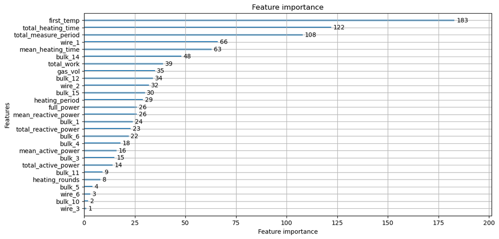

```python
plot_importance(lgbm_cv_model, figsize=figsize);
```

### Рекомендации заказчику:

Таким образом:

- Для целей прогнозирования непосредственно температуры действительно рекомендуется использовать обученную модель LightGBM регрессора
- Для аналитических целей и для понимания взаимосвязи признаков рекомендуется использовать модель линейной регрессии.

## Отчет по решению

### Постановка задачи и проблемы реализации

Для оптимизации производственных расходов, металлургический комбинат ООО «Так закаляем сталь» решил уменьшить потребление электроэнергии на этапе обработки стали. Для выполнения этой задачи нужно было подобрать, обучить и протестировать прогнозную модель машинного обучения, которая по начальным условиям предсказывала бы итоговую температуру расплава с точностью не ниже MAE 6,0 градусов.

Эта работа была проделана в рамках данного проекта согласно разработанному плану:

- **Подготовка данных и исследовательский анализ**
  - Загрузка и знакомство с данными
  - Проверка корректности данных и графический анализ распределения признаков
- **Предобработка данных**
  - Выбор и подготовка признаков, необходимых для ML моделей
  - Генерация новых признаков
  - Сведение признаков в единую структуру данных
  - Корреляционный анализ взаимозависимости признаков
  - Разделение данных на обучающую и тестовую выборки
  - Выделение целевого признака
  - Заполнение или удаление пробелов и выбросов в данных
  - Приведение и оптимизация типов данных
- **Построение и обучение моделей машинного обучения**
  - Обучение различных моделей с оценкой их качества кросс-валидацией, выбор лучшей
  - Проверка выбранной модели на тестовой выборке
- **Формулирование итоговых выводов**
  - Подготовка и описание результатов исследования
  - Выработка рекомендаций
  - Составление отчета заказчику

Для выполнения задачи нужно было выполнить следующие шаги:

- Описать и проанализировать данные
- Обработать данные, очистив их от аномалий и выбросов и подготовить их для моделирования, выделив необходимые признаки
- Провести обучение моделей машинного обучения на подготовленных данных и протестировать выбранную модель на предмет достижения поставленной цели по качеству предсказания

Все пункты данного плана были выполнены. В ходе выполнения проекта возникли трудности с организацией признаков по времени: модели машинного обучения не показали удовлетворительных результатов на структуре данных, оформленной таким образом, следствием чего стал отказ от этой структуры и переход к агрегации признаков по ключу (параметру `key`, общему для всех файлов)

### Описание и анализ данных

Данные предоставлены в виде набора из семи файлов:

- data_arc_new.csv — данные об электродах;
- data_bulk_new.csv — данные о подаче сыпучих материалов (объём);
- data_bulk_time_new.csv — данные о подаче сыпучих материалов (время);
- data_gas_new.csv — данные о продувке сплава газом;
- data_temp_new.csv — результаты измерения температуры;
- data_wire_new.csv — данные о проволочных материалах (объём);
- data_wire_time_new.csv — данные о проволочных материалах (время).

В данных имелись аномалии и пропуски:

- Аномальный минимум (отрицательное число) значения признака `Реактивная мощность` (файл `data_arc_new.csv`) по ключу `2116`. Скорее всего это ошибка в данных.
- Значения температуры меньше 1500 в `data_temp_new.csv`, чего согласно данным с завода быть не может.
- Обнаружены пропуски в файлах `data_bulk_new.csv`, `data_bulk_time_new.csv`, `data_temp_new.csv`, `data_wire_new.csv`, `data_wire_time_new.csv`.
- В датафреймах, полученных из файлов, обнаружено несоответсвие типов данных для некоторых столбцов, на этапе предобработки это было исправлено.
- Были обнаружены непригодные признаки (всего с одним наблюдением) `Wire 5` (файл `data_wire_new.csv`) и `Bulk 8` (файл `data_bulk_new.csv`), на этапе предобработки эти признаки удалены.
- Найдены выбросы в признаках `Газ 1`, `Bulk 5`, `Bulk 12`, которые также удалены на этапе предобработки

### Работа с признаками и предобработка данных

Для целей предсказания признака `Последняя температура` из данных были отобраны и созданы следующие признаки:

- Отобранные: `Первая температура`, `Bulk 1`, `Bulk 2`, `Bulk 3`, `Bulk 4`, `Bulk 5`, `Bulk 6`, `Bulk 7`, `Bulk 9` `Bulk 10`, `Bulk 11`, `Bulk 12`, `Bulk 13`, `Bulk 14`, `Bulk 15`, `Wire 1`, `Wire 2`, `Wire 3`, `Wire 4`, `Wire 6` `Wire 7`, `Wire 8`, `Wire 9`, `Газ 1`
- Созданные: `Количество циклов нагрева`, `Среднее время нагрева`, `Общее время нагрева`, `Общий период измерений`, `Дельта нагрева`, `Средняя активная мощность`, `Средняя реактивная мощность`, `Суммарная активная мощность`, `Суммарная реактивная мощность`

Итоговый набор признков был сведен в общий датафрейм `merged_df`

Корреляционный анализ показал крайне сильную линейную взаимосвязь между признаками `Активной мощности` и `Реактивной мощности`. Из-за чего показатель `Реактивной мощности` был удален при обучении модели линейной регрессии, чтобы избежать проблем с мультиколлинеарностью. Также была замечена сильная линейная взаимосвязь между признаками `Количесто циклов нагрева` и `Сумарными активными/реактивными мощностями`

Пробелы и выбросы в данных были удалены:

- пробелы в признаках из групп `Bulk *` и `Wire *` означали, что эти материалы просто не добавлялиь, а потому заменены нулями
- обнаруженные на основе графического анализа диаграмм размаха (boxplot) выбросы в признаках `Количество циклов нагрева`, `Общее время нагрева`, `Средняя активная мощность` `Суммарная активная мощность`, `Общий период измерений`, `Газ 1`, `Bulk 5`, `Bulk 12` удалялись.

Также была проведена оптимизация типов данных с целью уменьшения потребления памяти\процессорного времени.

После предобработки набор данных из файла `merged_df` был разделен на обучающую и тестовую выборки.

### Характеристика выбранной модели

Для обучения были выбраны 4 регрессионные модели:

- Константная baseline модель (DummyRegressor, sklearn), предсказывающая целевой признак по среднему значению;
- Линейная регрессия (LinearRegressor, sklearn);
- Случайный лес (RandomForest, sklearn);
- Градиентный бустинг (LGBMRegressor, lightgbm)

По результатам проведенного методом кросс-валидации обучения была отобрана регрессионная модель LightGBM, показавшая такие результаты:

```python
training_stats.sort_values(by='(train CV) MAE')
```

| Модель | (train CV) MAE |
| --- | --- |
| LightGBM | 5.83 |
| Линейная регрессия | 5.85 |
| Случайный лес | 6.07 |

Эти результаты были получены со следующими гиперпараметрами модели:

```python
models[best_model][1]
```

```
{'lambda_l1': 0.56,
 'lambda_l2': 0.056,
 'learning_rate': 0.0955,
 'max_bin': 160,
 'num_leaves': 11}
```

Наиболее важными признаками для данной прогнозной модели стали: `Первая температура`, `Общее время нагрева` и `Общий период измерений`.

Привожу график важности признаков:

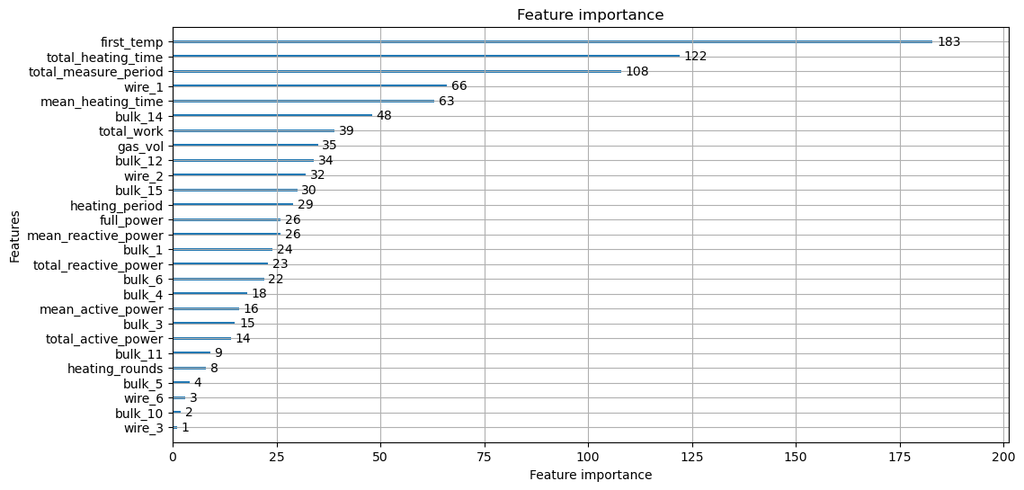

[output not shown]

[output cut: 126 more lines]

[output not shown]

```python
plot_importance(lgbm_cv_model, figsize=figsize);
```